# POLS 503: Problem Set 3

# Problems

The problems of this assignment will use various simulations similar to the one in the previous section. For all simulations use `iter = 1024`. If this is taking too long you can reduce the number of iterations.

```r
iter <- 1024
```

## Linear Normal Model with Homoskedasticity

In this problem, we will use `sim_lin_norm` to understand how OLS recovers parameters when the population meets the Gauss-Markov assumptions.
$$\begin{aligned}[t]
Y_i &= 0 + 1 \cdot x_{1,i} + 1 \cdot x_{2,i} + 1 \cdot x_{3,i} + \epsilon_i \\
\epsilon_i &\sim N(0, \sigma^2) \\
\sigma &= 1.7
\end{aligned}$$
The covariates, $X$, are independent, with means, $\mu_{X,j} = 0$, and standard deviations, $s_{X,j} = 1$ for all variables. The sample size $n$ will vary with simulation.

You would want to set these variables to use in a simulation

```r
mu_X <- c(0, 0, 0)
s_X <- c(1, 1, 1)
R_X <- diag(3)
beta <- c(0, 1, 1, 1)
sigma <- 1.7
```

Run several simulations with `sim_lin_norm` varying the sample size to determine how sample size affects the following: $n = \{32, 64, 512, 1024 \}$. We will store these in a vector to use later:

```r
n_samples <- c(32, 64, 512, 1024)
```

As shown in the introduction, you can use `sim_lin_norm` to simulate for a single sample size as follows. E.g. for sample size 32, we could run

```r
n <- 32
summarize_sim(sim_lin_norm(iter = iter, n = n,
                           mu_X = mu_X, s_X = s_X, R_X = R_X,
                           beta = beta, sigma = sigma),
              beta = beta)
```

```
## Source: local data frame [4 x 7]
##
##          term estimate_mean estimate_sd   se_mean se_robust_mean  iter
##         (chr)         (dbl)       (dbl)     (dbl)          (dbl) (int)
## 1 (Intercept)  0.0005568472   0.3108692 0.2971834      0.3188141  1024
## 2          X1  1.0126230961   0.3077340 0.3019387      0.3277490  1024
## 3          X2  1.0113121762   0.3025391 0.3019387      0.3274915  1024
## 4          X3  1.0049486912   0.3257556 0.3019387      0.3337626  1024
## Variables not shown: beta_true (dbl)
```

In order to run this for *all* the different sample sizes, we will put this in a list

```r
sims1 <- list()
# Loop over the integers 1 to the number of different sample sizes.
for (i in 1:length(n_samples)) {
  # Run simulation
  sim_results <- sim_lin_norm(iter, n_samples[i], mu_X, s_X, R_X, beta, sigma)
  # Summarize simmulations
  sim_summ <- summarize_sim(sim_results, beta)
  # Add a new column to the data to indicate which sample size this simulation used
  sim_summ[["n"]] <- n_samples[i]
  # Save the data to the list in location i
  sims1[[i]] <- sim_summ
}
sims1 <- bind_rows(sims1)
```

Then use these results to analyze the following:

- The bias of each $\hat{\beta}_j$. How different is `estimate_mean` ($\hat\beta$) from `beta_true` ($\beta$)?
- The standard deviation of $\hat{\beta}_j$?. How does `estimate_sd` change as the sample size increases?
- The bias of the standard error of each $\hat{\beta}_j$. Compare the actual population standard deviations, `estimate_sd`, with the means of the standard errors, `se_mean`.
- The bias of the robust standard error of each $\hat{\beta}_j$? Compare the actual population standard deviations of each parameter, `estimate_sd`, with the means of the robust standard errors, `se_robust_mean`.

As an example, to find the bias of $\hat\beta$:

```r
sims1 %>%
  mutate(bias = estimate_mean - beta_true) %>%
  select(term, n, bias, estimate_mean, beta_true)
```

```
## Source: local data frame [16 x 5]
##
##           term     n          bias estimate_mean beta_true
##          (chr) (dbl)         (dbl)         (dbl)     (dbl)
## 1  (Intercept)    32  0.0011815989   0.001181599         0
## 2           X1    32 -0.0097611034   0.990238897         1
## 3           X2    32  0.0081029412   1.008102941         1
## 4           X3    32 -0.0066576047   0.993342395         1
## 5  (Intercept)    64 -0.0038729618  -0.003872962         0
## 6           X1    64  0.0068974374   1.006897437         1
## 7           X2    64  0.0096966727   1.009696673         1
## 8           X3    64 -0.0105326061   0.989467394         1
## 9  (Intercept)   512 -0.0044628492  -0.004462849         0
## 10          X1   512 -0.0017342706   0.998265729         1
## 11          X2   512 -0.0051168685   0.994883131         1
## 12          X3   512  0.0018413502   1.001841350         1
## 13 (Intercept)  1024 -0.0023254669  -0.002325467         0
## 14          X1  1024 -0.0033017425   0.996698257         1
## 15          X2  1024  0.0006139221   1.000613922         1
## 16          X3  1024 -0.0042032124   0.995796788         1
```

Use similar analysis for the other questions.

## Correlated Variables

In the previous problem, the covariates were assumed to be independent. Now, we will evaluate the properties of OLS estimates when covariates are correlated. As before, the population is
$$\begin{aligned}[t]
Y_i &= 0 + 1 \cdot x_{1,i} + 1 \cdot x_{2,i} + 1 \cdot x_{3,i} + \epsilon_i \\
\epsilon_i &\sim N(0, \sigma^2) \\
\sigma &= 1.7
\end{aligned}$$
In this problem keep $\mu_X = (0, 0, 0)$ and $s_X = (1, 1, 1)$, but $R_X$ will differ between simulations to allow for different levels of correlation between $x_1$ and $x_2$. The covariate $x_3$ is independent of the other covariates, $\cor(x_1, x_3) = \cor(x_2, x_3) = 0$. Thus, the correlation matrix for $X$ in these simulations is the following, where $\rho_{1,2}$ will vary:
$$R_X =
\begin{bmatrix}
1 & \rho_{1,2} & 0 \\
\rho_{1,2} & 1 & 0 \\
0 & 0 & 1
\end{bmatrix}$$

Use $n = 1024$ for all simulations.

Simulate using `sim_lin_normal` with the following levels of correlation between $x_1$ and $x_2$ ($\rho_{1,2}$): 0, 0.5, 0.95, -0.5, -0.95. Based on the results of those simulations, how does $\cor(x_1, x_2)$ affect the following?

- The bias of each $\hat{\beta}_j$?
- The variance of each $\hat{\beta}_j$?
- The bias of the standard error of each $\hat{\beta}_j$?
- The bias of the robust standard error of each $\hat{\beta}_j$?

Remember to consider the effects of correlation on *all* the estimates: $\hat{\beta}_1$, $\hat{\beta}_2$, and $\hat{\beta}_3$.

## Collinearity

Use the same settings in the previous question, but set $\cor(x_1, x_2) = 1$. What happens? Why?

## P-values, Type I and II errors

- For each parameter, plot the distribution of $p$-values across iterations. Describe the densities.
- For each parameter, calculate the proportion of $p$-values less than 0.05 for each parameter. Suppose a null hypothesis of $H_0: \beta_i = 0$ and an alternative hypothesis of $H_a: \beta_i \neq 0$. For which parameters is $H_0$ true, for which parameters is $H_a$ true? What is the probability of a Type I or Type II error for each parameter.
- For each parameter, plot the distribution of its estimates *conditional* on it being significant at $p < 0.05$. How does the sampling distribution conditional on statistical significance relate to the unconditional sampling distribution?
- Repeat each of those analyses using a smaller sample size, $n = 32$, and a larger sample size $n = 1024$. What changes, if anything?

## Omitted Variable Bias

The population is
$$\begin{aligned}[t]
Y_i &= 0 + 1 \cdot x_{1,i} + 1 \cdot x_{2,i} + 1 \cdot x_{3,i} + \epsilon_i \\
\epsilon_i &\sim N(0, \sigma^2) \\
\sigma &= 1.7
\end{aligned}$$

In all simulations, $(x_1, x_2)$ and $(x_2, x_3)$ are uncorrelated. The correlation between $x_1$ and $x_3$ will vary between simulations. In other words, the correlation matrix for the $x$ variables is
$$R =
\begin{bmatrix}
1 & 0 & \rho_{1,3} \\
0 & 1 & 0 \\
\rho_{1,3} & 0 & 1
\end{bmatrix}$$

In all simulations, the sample regression will only include $x_1$ and $x_2$:
$$y_i = \hat\beta_0 + \hat\beta_1 x_{1,i} + \hat\beta_2 x_{2,i} + \hat\epsilon_i$$
Use $n = 1024$ for all simulations.

You can perform this simulations of this scenario using the function, `sim_lin_norm_omitted`, which samples from a linear, normal model with homoskedastic errors, but allows you to run a misspecified regression on the samples by omitting variables. The arguments to this function are the same as `sim_lin_norm` except for

**`omit`**

A vector of integers of the columns to omit from X when estimating the sample regression. Set `omit = 3` to omit the 3rd covariate.

To run a simulation for a single value of $\rho_{1,3}$:

```r
n <- 1024
mu_X <- c(0, 0, 0)
s_X <- c(1, 1, 1)
rho <- 0
R_X <- matrix(c(1, 0, rho,
                0, 1, 0,
                rho, 0, 1), byrow = TRUE, nrow = 3)
beta <- c(0, 1, 1, 1)
sigma <- 1.7
sim_lin_norm_omitted(iter = iter, n = n, mu_X = mu_X,
                     s_X = s_X, R_X = R_X, beta = beta,
                     sigma = sigma, omit  = 3)
```

Warning: when using `summarize_sim` remember that the parameters of the population are not equal the parameters that are estimated.

Consider the following values of the correlation between $x_1$ and $x_3$ ($\rho_{1,3}$): 0, 0.1, 0.7, -0.7, 0.99, -0.99. How does the correlation of variables affect:

- The bias of each $\hat{\beta}_j$?
- The variance of each $\hat{\beta}_j$?
- The bias of the standard error of each $\hat{\beta}_j$?
- The bias of the robust standard error of each $\hat{\beta}_j$?

## Heteroskedasticity

In this problem, we will explore how heteroskedasticity affects OLS estimates. In these simulations, we will use a population model with heteroskedasticity
$$\begin{aligned}[t]
Y_i &= 0 + 1 \cdot x_1 + 1 \cdot x_2 \epsilon_i \\
\epsilon_i &\sim N(0, \sigma^2_i) \\
\log \sigma_i^2 &= \gamma_0 + \gamma_1 x_1 + \gamma_2 \cdot x_2
\end{aligned}$$

The function `sim_lin_norm_hereosked` will run simulations using those specifications of the population ans ample. The arguments for it are the same as `sim_lin_norm` except that instead of the argument `sigma` for the standard deviation of the errors, it has the argument `gamma`:

**`gamma`**

A vector of coefficients for $\log \sigma^2 = \gamma_0 + \gamma_1 x_1 + \dots + \gamma_k x_k$. Like `beta` it should have length `k + 1`.

First, set the values for this simulation:

```r
n <- 1024
mu_X <- c(0, 0)
s_X <- c(1, 1)
R_X <- diag(2)
beta <- c(0, 1, 1)
gamma0 <- 1.5
gamma2 <- 0
```

Create a vector when $\gamma_1 = 0$,

```r
gamma1_values <- c(0, 0.2, 0.7)
```

To give a better sense of what heteroskedasticity at various values of $\gamma_1$ correspond to, the following plot displays a scatter plot and a regression line for different values of $\gamma_1$:

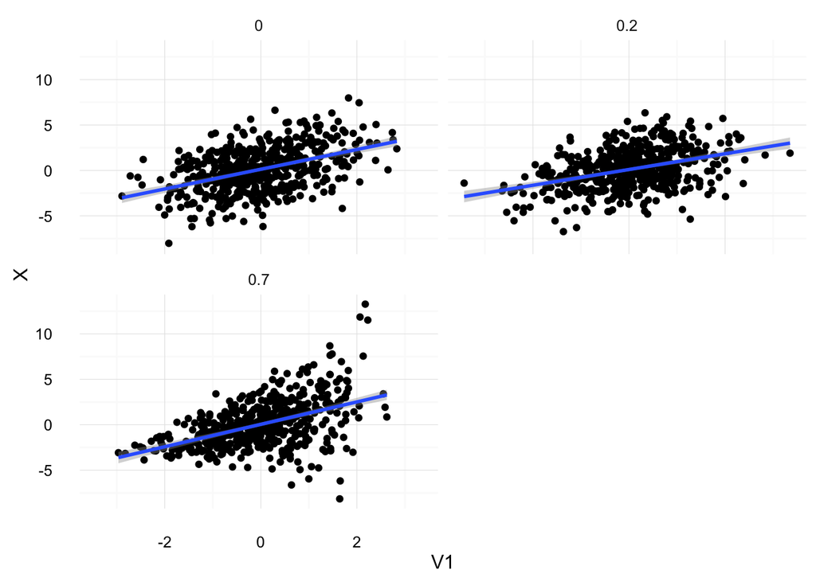

For given values, you can run `sim_lin_norm_heterosked`:

```r
gamma1 <- gamma1_values[1]
gamma <- c(gamma0, gamma1, gamma2)
sim_lin_norm_heterosked(iter = iter, n = n, mu_X = mu_X,
                        s_X = s_X, R_X = R_X, beta = beta, gamma = gamma)
```

For these simulations, you will need to loop over the various values of $\gamma_1$ stored in `gamma1_values`.

Use `sim_lin_norm_heterosked` to evaluate how the level of heteroskedasticity affects:

- the bias of each $\hat{\beta}_j$?
- the variance of each $\hat{\beta}_j$?
- the bias of the standard error of each $\hat{\beta}_j$?
- the bias of the robust standard error of each $\hat{\beta}_j$?

Remember to consider how heteroskedasticity in $x_1$ affects the estimates of heteroskedasticity in $x_2$.

## Truncated Dependent Variable (optional)

**You do not need to do this**

This problem considers what happens when there is a truncated dependent variable. This is also called sampling on the dependent variable, which is a research design problem not unknown to political science research.[^2]

The population is a linear normal model with homoskedastic errors.
$$\begin{aligned}[t]
Y_1 &= \beta_0 + \beta_1 x_{1,i} + \dots + \beta_k x_{k,i} + \epsilon_i \\
\epsilon_i &\sim N(0, \sigma^2)
\end{aligned}$$
However, in each sample, all $y_i$ which are less than a quantile $q$ are dropped before the regression is estimated.
$$\begin{aligned}[t]
y_i = \beta_0 + \hat\beta_1 x_{1,i} + \dots + \hat\beta_k x_{k,i} + \hat\epsilon \\ \text{if $y_i \geq \quantile(y, q)$}
\end{aligned}$$
where $\quantile(y, q)$ is the $q$th quantile of $y$. For example, if $q = 0.5$, all $y_i$ that are less than the median of $y$ (the bottom 50%) are dropped.

The function `sim_lin_norm_truncated`, is similar to the `sim_lin_norm` function except for the argument

**`truncation`**

The quantile of truncation. All sampled $y_i$ with values less than that quantile are dropped before the regression is run. The default value `truncation = 0.5` means all values of $y$ less than the median are dropped before running the regression.

Run several simulations with `sim_lin_normal_truncated` and vary the sample size. How does the sample size affect the following:

- The bias of each $\hat{\beta}_j$?
- The variance of each $\hat{\beta}_j$?

In particular, if we gather more data but $y$ is truncated, does it decrease the bias in $\hat{\beta}$?

Derived from of Christopher Adolph, “Problem Set 3”, *POLS/CSSS 503*, University of Washington, Spring 2014. http://faculty.washington.edu/cadolph/503/503hw3.pdf. Used with permission.

[^1]: Although the statistical theory of OLS works (thankfully) for random $X$, as long as certain conditions are met. See Fox (2nd ed.), Ch 9.6.
[^2]: See Ashworth, Scott, Joshua D. Clinton, Adam Meirowitz, and Kristopher W. Ramsay. 2008. ``Design, Inference, and the Strategic Logic of Suicide Terrorism.’’ *American Political Science Review() 102(02): 269–73. http://journals.cambridge.org/article_S0003055408080167

This work is licensed under a [Creative Commons Attribution-NonCommercial-ShareAlike 4.0 International License](http://creativecommons.org/licenses/by-nc-sa/4.0/). R code is licensed under a [BSD 2-clause](http://www.r-project.org/Licenses/BSD_2_clause) license.